# Case Study

## All Risk Classes and types aggregated together

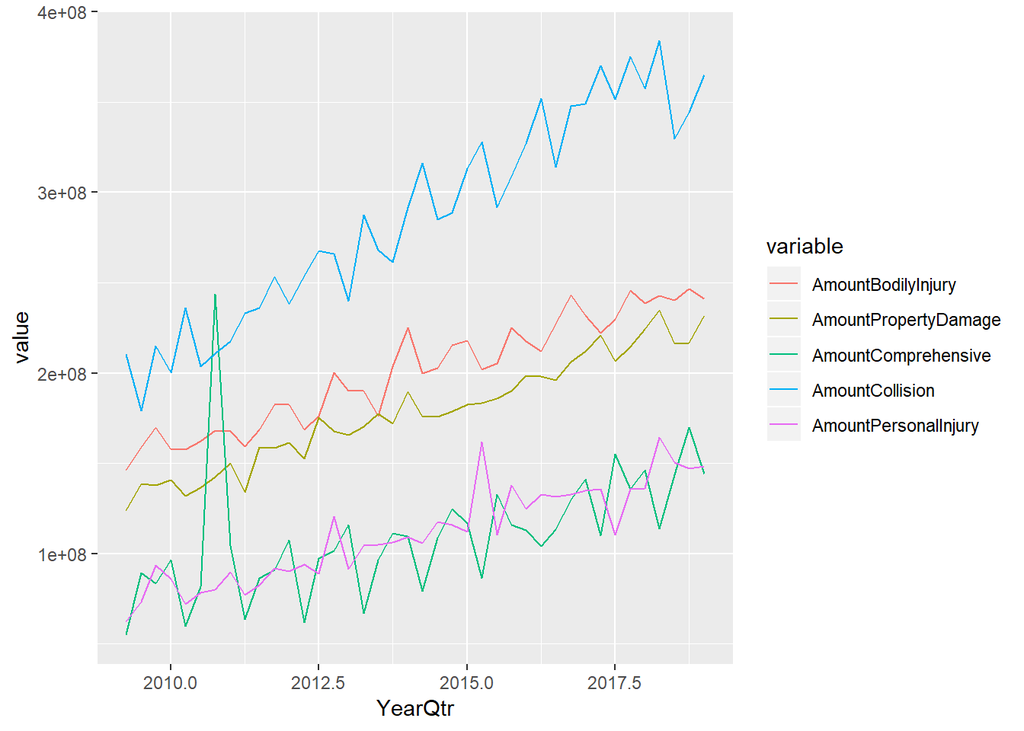

```r
# But if we aggregate The Risk classes??
autoclaims.Qtrly <- aggregate(. ~ Year + Qtr+ YearQtr, autoclaims[, !(names(autoclaims) %in% c("Type", "RiskClass") )], FUN = sum)

melt.autoclaims.Qtrly <- melt(autoclaims.Qtrly, id = c("Year", "Qtr", "YearQtr"))
ggplot(data = melt.autoclaims.Qtrly[ !(melt.autoclaims.Qtrly$variable %in% c("TotalExposure", "ExposureNormalize", "NoPropertyDamage",
                                                                             "NoComprehensive", "NoCollision", "NoBodilyInjury", "NoPersonalInjury", "CarYearsOfExposure")), ]) + geom_line(aes( x = YearQtr, y = value, color = variable ))
```

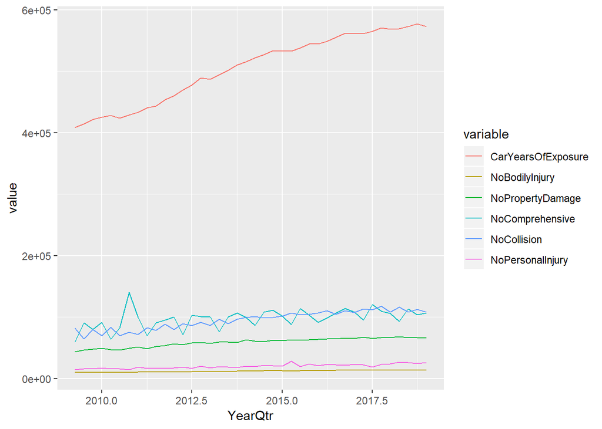

```r
ggplot(data = melt.autoclaims.Qtrly[ !(melt.autoclaims.Qtrly$variable %in% c("TotalExposure", "ExposureNormalize", "AmountPropertyDamage",
                                                                             "AmountComprehensive", "AmountCollision", "AmountBodilyInjury", "AmountPersonalInjury")), ]) + geom_line(aes( x = YearQtr, y = value, color = variable ))
```

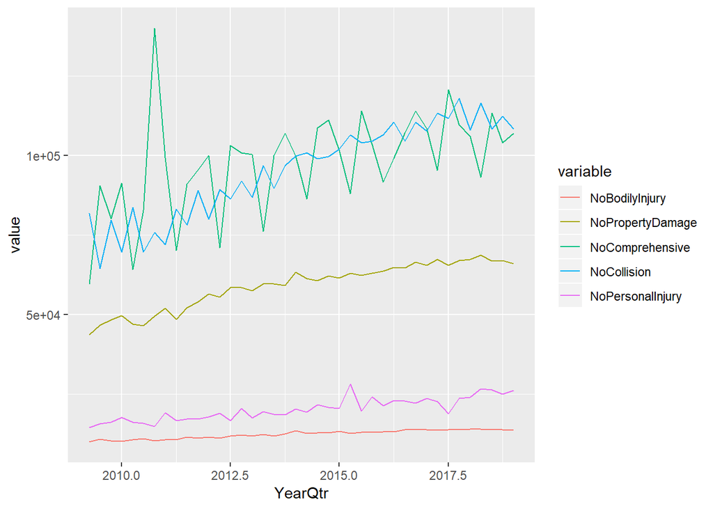

```r
ggplot(data = melt.autoclaims.Qtrly[ !(melt.autoclaims.Qtrly$variable %in% c("TotalExposure", "ExposureNormalize", "AmountPropertyDamage",
                                                                             "AmountComprehensive", "AmountCollision", "AmountBodilyInjury", "AmountPersonalInjury", "CarYearsOfExposure")), ]) + geom_line(aes( x = YearQtr, y = value, color = variable ))
```

When looked at the whole policies as one the spikes disappear (but there is some seasonality) but there is still a spike at year 2010 quarter 3. So this one is definitely an outlier and needs to be replaced by some method or deleted.

## Looking into proportions

To the porportions of the claim amount in each group stay relatively the same?

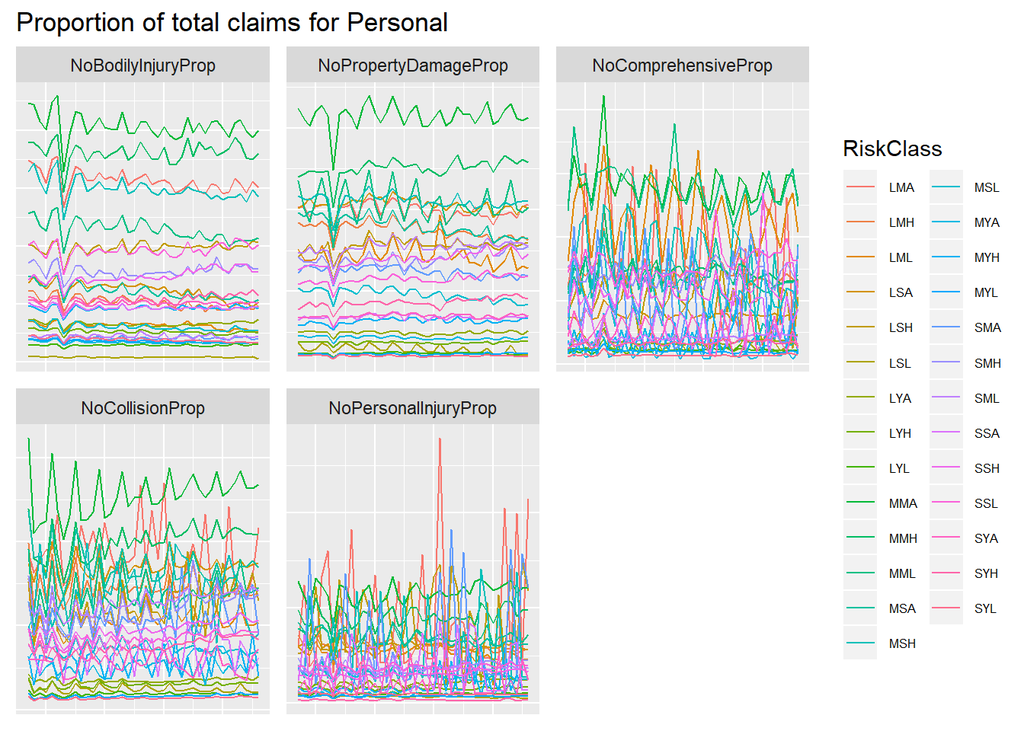

```r
autoclaims$totalNoClaims <-0
for( i in levels(factor(autoclaims$Year))){
  for(j in levels(factor(autoclaims$Qtr))){

    autoclaims$totalNoClaims[autoclaims$Year == i & autoclaims$Qtr == j] <- sum(autoclaims$NoBodilyInjury[autoclaims$Year == i & autoclaims$Qtr == j] ) +
      sum(autoclaims$NoPropertyDamage[autoclaims$Year == i & autoclaims$Qtr == j] ) +
    sum(autoclaims$NoComprehensive[autoclaims$Year == i & autoclaims$Qtr == j] ) +
      sum(autoclaims$NoCollision[autoclaims$Year == i & autoclaims$Qtr == j] ) +
      sum(autoclaims$NoPersonalInjury[autoclaims$Year == i & autoclaims$Qtr == j] )

  }
}
# total number of claims
autoclaims$NoBodilyInjuryProp <- autoclaims$NoBodilyInjury/autoclaims$totalNoClaims
autoclaims$NoPropertyDamageProp <- autoclaims$NoPropertyDamage/autoclaims$totalNoClaims
autoclaims$NoComprehensiveProp <- autoclaims$NoComprehensive/autoclaims$totalNoClaims
autoclaims$NoCollisionProp <- autoclaims$NoCollision/autoclaims$totalNoClaims
autoclaims$NoPersonalInjuryProp <- autoclaims$NoPersonalInjury/autoclaims$totalNoClaims

# Total Expsoure prop
autoclaims$NoBodilyInjuryPropE <- autoclaims$NoBodilyInjury/autoclaims$TotalExposure
autoclaims$NoPropertyDamagePropE <- autoclaims$NoPropertyDamage/autoclaims$TotalExposure
autoclaims$NoComprehensivePropE <- autoclaims$NoComprehensive/autoclaims$TotalExposure
autoclaims$NoCollisionPropE <- autoclaims$NoCollision/autoclaims$TotalExposure
autoclaims$NoPersonalInjuryPropE <- autoclaims$NoPersonalInjury/autoclaims$TotalExposure

# data frame only with prop  yearly qtr
autoclaims.prop <- autoclaims[, names(autoclaims) %in% c("YearQtr", "RiskClass", "Type", "NoBodilyInjuryProp", "NoPropertyDamageProp", "NoComprehensiveProp", "NoCollisionProp", "NoPersonalInjuryProp"), drop = F]

# data frame only with propE and yearly qtr
autoclaims.propE <- autoclaims[, names(autoclaims) %in% c("YearQtr", "RiskClass", "Type", "NoBodilyInjuryPropE", "NoPropertyDamagePropE", "NoComprehensivePropE", "NoCollisionPropE", "NoPersonalInjuryPropE"), drop = F]


melt.autoclaims.prop <- melt(autoclaims.prop, id = c("YearQtr", "RiskClass", "Type"))

ggplot(data = melt.autoclaims.prop[melt.autoclaims.prop$Type == "Personal" ,]) + geom_line(aes(x = YearQtr, y = value, color =RiskClass)) + facet_wrap(. ~variable, scales = "free") + ggtitle("Proportion of total claims for Personal ")+
    theme(axis.title.x=element_blank(),
          axis.text.x=element_blank(),
          axis.ticks.x=element_blank(),
          axis.title.y=element_blank(),
          axis.text.y=element_blank(),
          axis.ticks.y=element_blank(),
          legend.text=element_text(size=6)) +
    guides(col = guide_legend(ncol = 2, byrow = F))
```

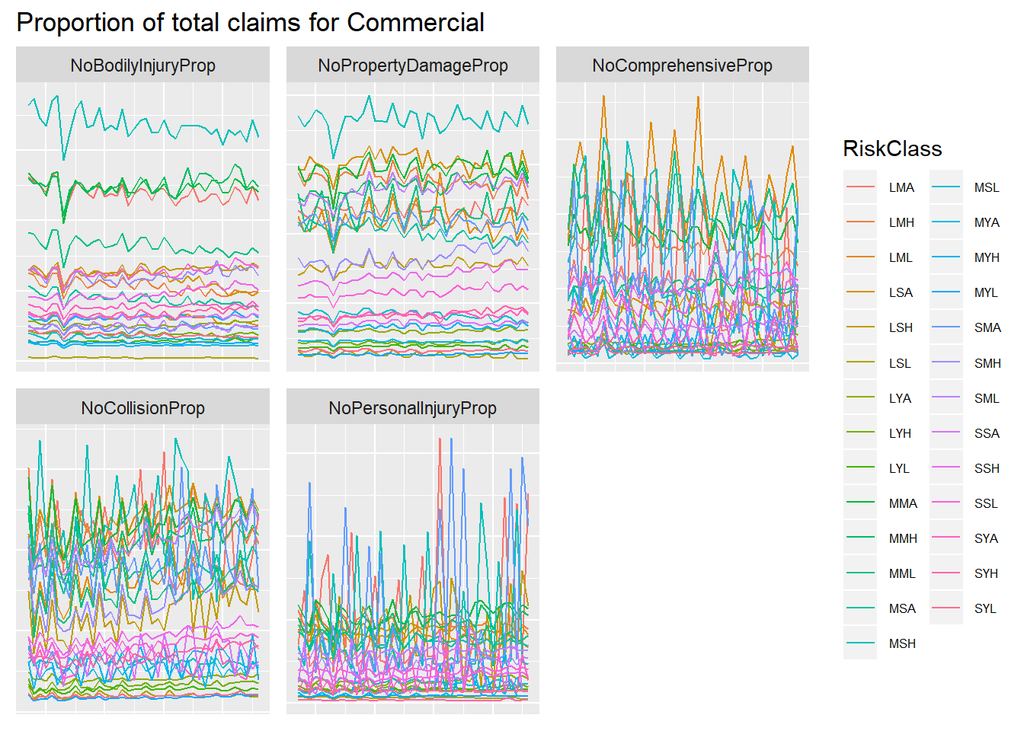

```r
ggplot(data = melt.autoclaims.prop[melt.autoclaims.prop$Type == "Commercial",]) + geom_line(aes(x = YearQtr, y = value, color =RiskClass)) + facet_wrap(. ~variable, scales = "free") + ggtitle("Proportion of total claims for Commercial ")+
    theme(axis.title.x=element_blank(),
          axis.text.x=element_blank(),
          axis.ticks.x=element_blank(),
          axis.title.y=element_blank(),
          axis.text.y=element_blank(),
          axis.ticks.y=element_blank(),
          legend.text=element_text(size=6)) +
    guides(col = guide_legend(ncol = 2, byrow = F))
```

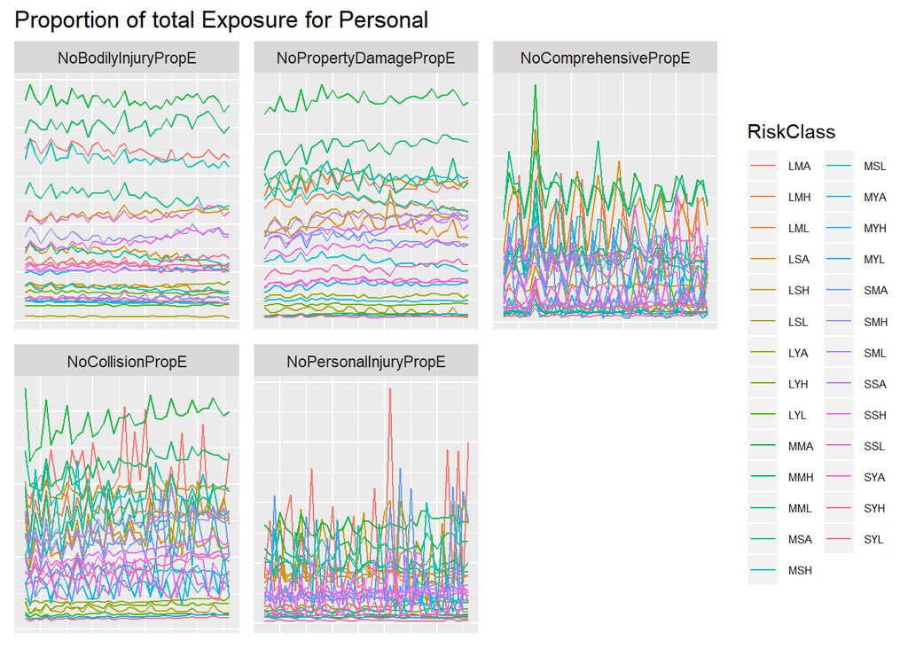

```r
melt.autoclaims.propE <- melt(autoclaims.propE, id = c("YearQtr", "RiskClass", "Type"))

ggplot(data = melt.autoclaims.propE[melt.autoclaims.propE$Type == "Personal",]) + geom_line(aes(x = YearQtr, y = value, color =RiskClass)) + facet_wrap(. ~variable, scales = "free") + ggtitle("Proportion of total Exposure for Personal ")+
    theme(axis.title.x=element_blank(),
          axis.text.x=element_blank(),
          axis.ticks.x=element_blank(),
          axis.title.y=element_blank(),
          axis.text.y=element_blank(),
          axis.ticks.y=element_blank(),
          legend.text=element_text(size=6)) +
    guides(col = guide_legend(ncol = 2, byrow = F))
```

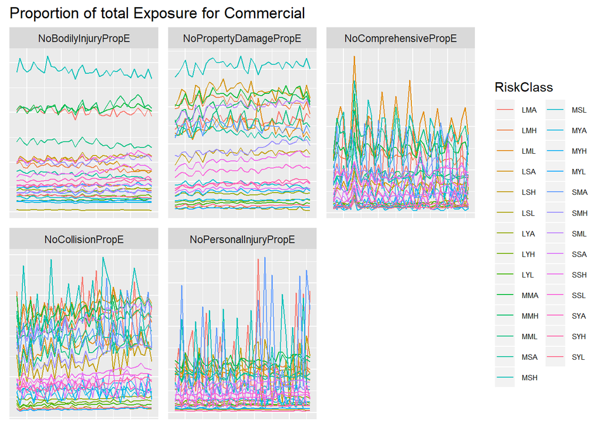

```r
ggplot(data = melt.autoclaims.propE[melt.autoclaims.propE$Type == "Commercial",]) + geom_line(aes(x = YearQtr, y = value, color =RiskClass)) + facet_wrap(. ~variable, scales = "free") + ggtitle("Proportion of total Exposure for Commercial ")+
    theme(axis.title.x=element_blank(),
          axis.text.x=element_blank(),
          axis.ticks.x=element_blank(),
          axis.title.y=element_blank(),
          axis.text.y=element_blank(),
          axis.ticks.y=element_blank(),
          legend.text=element_text(size=6)) +
    guides(col = guide_legend(ncol = 2, byrow = F))
```

Again so clustered Lets look at the drivers Risk

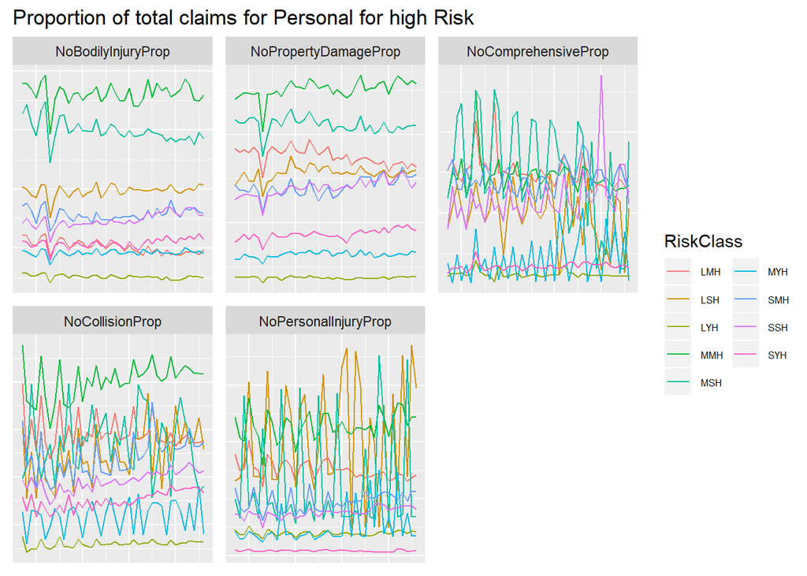

```r
ggplot(data = melt.autoclaims.prop[melt.autoclaims.prop$Type == "Personal" & grepl("H$", x = melt.autoclaims.prop$RiskClass),]) + geom_line(aes(x = YearQtr, y = value, color =RiskClass)) + facet_wrap(. ~variable, scales = "free") + ggtitle("Proportion of total claims for Personal for high Risk ")+
    theme(axis.title.x=element_blank(),
          axis.text.x=element_blank(),
          axis.ticks.x=element_blank(),
          axis.title.y=element_blank(),
          axis.text.y=element_blank(),
          axis.ticks.y=element_blank(),
          legend.text=element_text(size=6)) +
    guides(col = guide_legend(ncol = 2, byrow = F))
```

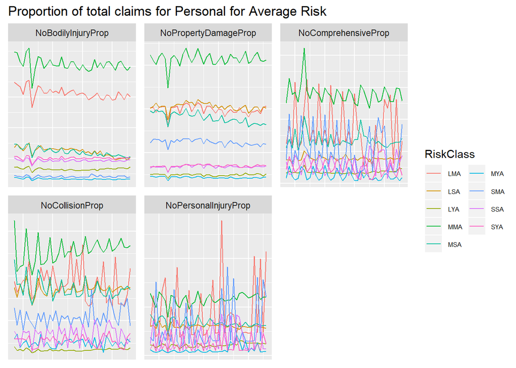

```r
ggplot(data = melt.autoclaims.prop[melt.autoclaims.prop$Type == "Personal" & grepl("A$", x = melt.autoclaims.prop$RiskClass),]) + geom_line(aes(x = YearQtr, y = value, color =RiskClass)) + facet_wrap(. ~variable, scales = "free") + ggtitle("Proportion of total claims for Personal for Average Risk ")+
    theme(axis.title.x=element_blank(),
          axis.text.x=element_blank(),
          axis.ticks.x=element_blank(),
          axis.title.y=element_blank(),
          axis.text.y=element_blank(),
          axis.ticks.y=element_blank(),
          legend.text=element_text(size=6)) +
    guides(col = guide_legend(ncol = 2, byrow = F))
```

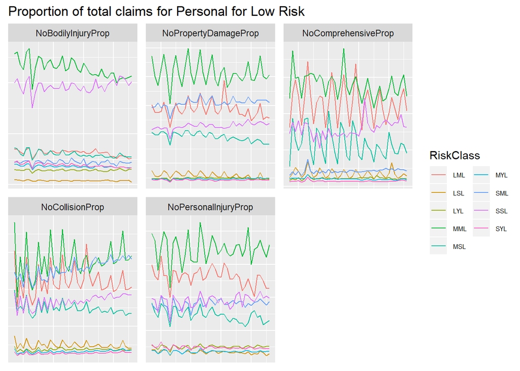

```r
ggplot(data = melt.autoclaims.prop[melt.autoclaims.prop$Type == "Personal" & grepl("L$", x = melt.autoclaims.prop$RiskClass),]) + geom_line(aes(x = YearQtr, y = value, color =RiskClass)) + facet_wrap(. ~variable, scales = "free") + ggtitle("Proportion of total claims for Personal for Low Risk ")+
    theme(axis.title.x=element_blank(),
          axis.text.x=element_blank(),
          axis.ticks.x=element_blank(),
          axis.title.y=element_blank(),
          axis.text.y=element_blank(),
          axis.ticks.y=element_blank(),
          legend.text=element_text(size=6)) +
    guides(col = guide_legend(ncol = 2, byrow = F))
```

Constant proprotions over seasons, but can be a lot of varation for one year (oscillations). Looks like the spikes are higher for high risk driver classes.

## Plot summary

We see a lot of oscillations especially for High Risk drivers depending on the quarter. But when everything is aggregated together there is only one sign of an outlier. The same goes for the proportions. The proportions seem stable but they can vary a lot depending on the season (quarter). From the porportion we can also see a spike at the outlier. The claim porportion goes down except for the Comprehensive variable as expected.